# Introduction to R

## t-tests

Doing t-tests in R is pretty straightforward:

```r
# One sample t-test to see if mean PC is different than 0
t.test(faceData$pc)
```

```
##
##  One Sample t-test
##
## data:  faceData$pc
## t = 39.958, df = 39, p-value < 2.2e-16
## alternative hypothesis: true mean is not equal to 0
## 95 percent confidence interval:
##  0.7274857 0.8050643
## sample estimates:
## mean of x
##  0.766275
```

```r
# two independent sample t-test to see if PC is different between younger and older
t.test(pc ~ faceOrient, data=faceData, var.equal=TRUE)
```

```
##
##  Two Sample t-test
##
## data:  pc by faceOrient
## t = -3.4761, df = 38, p-value = 0.001289
## alternative hypothesis: true difference in means is not equal to 0
## 95 percent confidence interval:
##  -0.18616616 -0.04913384
## sample estimates:
## mean in group inverted  mean in group upright
##                0.70745                0.82510
```

```r
# repeat above, but one-tailed test (is older PC less than younger PC?)
t.test(pc ~ faceOrient, data=faceData, var.equal=TRUE, alternative="less")
```

```
##
##  Two Sample t-test
##
## data:  pc by faceOrient
## t = -3.4761, df = 38, p-value = 0.0006446
## alternative hypothesis: true difference in means is less than 0
## 95 percent confidence interval:
##         -Inf -0.06058842
## sample estimates:
## mean in group inverted  mean in group upright
##                0.70745                0.82510
```

```r
# what if data from two groups had unequal variances?
t.test(pc ~ faceOrient, data=faceData, var.equal=FALSE)
```

```
##
##  Welch Two Sample t-test
##
## data:  pc by faceOrient
## t = -3.4761, df = 36.981, p-value = 0.001317
## alternative hypothesis: true difference in means is not equal to 0
## 95 percent confidence interval:
##  -0.18622819 -0.04907181
## sample estimates:
## mean in group inverted  mean in group upright
##                0.70745                0.82510
```

```r
# what if our data was paired-samples design?
t.test(pc ~ faceOrient, data=faceData, paired=TRUE)
```

```
##
##  Paired t-test
##
## data:  pc by faceOrient
## t = -5.265, df = 19, p-value = 4.413e-05
## alternative hypothesis: true difference in means is not equal to 0
## 95 percent confidence interval:
##  -0.16441972 -0.07088028
## sample estimates:
## mean of the differences
##                -0.11765
```

## ANOVA

One reason R is seen as a learning tool for statistics rather than just an analysis tool is that it demonstrates, by design, how many seemingly different statistical tests are *actually the same thing!*

To better appreciate that fact, keep in mind the format of the t-test function…

```r
# reminder of what a t-test looked like:
t.test(pc ~ faceOrient, data=faceData, var.equal=TRUE)
```

```
##
##  Two Sample t-test
##
## data:  pc by faceOrient
## t = -3.4761, df = 38, p-value = 0.001289
## alternative hypothesis: true difference in means is not equal to 0
## 95 percent confidence interval:
##  -0.18616616 -0.04913384
## sample estimates:
## mean in group inverted  mean in group upright
##                0.70745                0.82510
```

```r
# conducting a one-way ANOVA
oneWay.01 <- aov(pc ~ faceOrient, data=faceData)
summary(oneWay.01)
```

```
##             Df Sum Sq Mean Sq F value  Pr(>F)
## faceOrient   1 0.1384 0.13842   12.08 0.00129 **
## Residuals   38 0.4353 0.01146
## ---
## Signif. codes:  0 '***' 0.001 '**' 0.01 '*' 0.05 '.' 0.1 ' ' 1
```

```r
# can all be done in step...
summary(aov(pc ~ faceOrient, data=faceData))
```

```
##             Df Sum Sq Mean Sq F value  Pr(>F)
## faceOrient   1 0.1384 0.13842   12.08 0.00129 **
## Residuals   38 0.4353 0.01146
## ---
## Signif. codes:  0 '***' 0.001 '**' 0.01 '*' 0.05 '.' 0.1 ' ' 1
```

```r
#  t-tests and ANOVAs *are the same test*
# but ANOVA allows for multiple groups and factors.
# When only 2 groups, F = t^2... or t = sqrt(F)
sqrt(12.08)
```

```
## [1] 3.475629
```

## Factorial ANOVA

Factorial ANOVAs are just an extension of one-way ANOVAs.

Revisiting what the data in `faceData` looks like, we can see that there’s another column, `ageGroup` that we have been ignoring. Turns out half of the participants in this simulated experiment were older adults, and half were younger adults. We know that older adults are not as good as younger adults at identifying faces. The quesion is, is the Face Inversion Effect different for younger and older adults? *What aspect of a factorial ANOVA will answer this question?*

```r
# our data.frame has another variable, ageGroup
summary(faceData)
```

```
##      subjID      ageGroup     faceOrient       pc               rt
##  subj1  : 1   older  :20   inverted:20   Min.   :0.5200   Min.   : 539.0
##  subj10 : 1   younger:20   upright :20   1st Qu.:0.6800   1st Qu.: 767.5
##  subj11 : 1                              Median :0.7390   Median : 839.5
##  subj12 : 1                              Mean   :0.7663   Mean   : 833.6
##  subj13 : 1                              3rd Qu.:0.8725   3rd Qu.: 918.0
##  subj14 : 1                              Max.   :0.9810   Max.   :1019.0
##  (Other):34
```

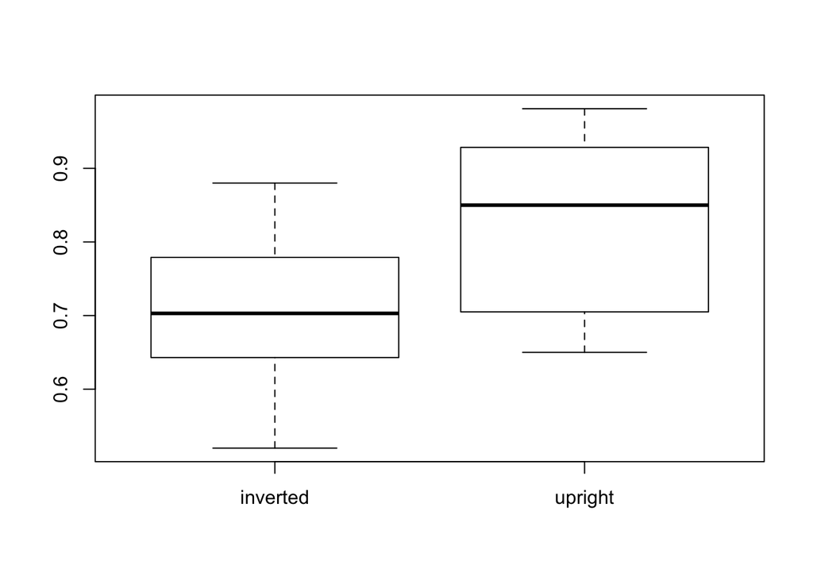

```r
boxplot(pc ~ faceOrient, data=faceData)
```

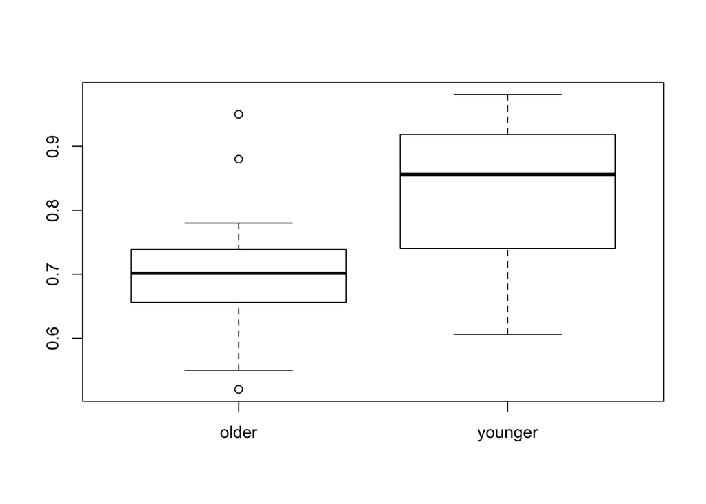

```r
boxplot(pc ~ ageGroup, data=faceData)
```

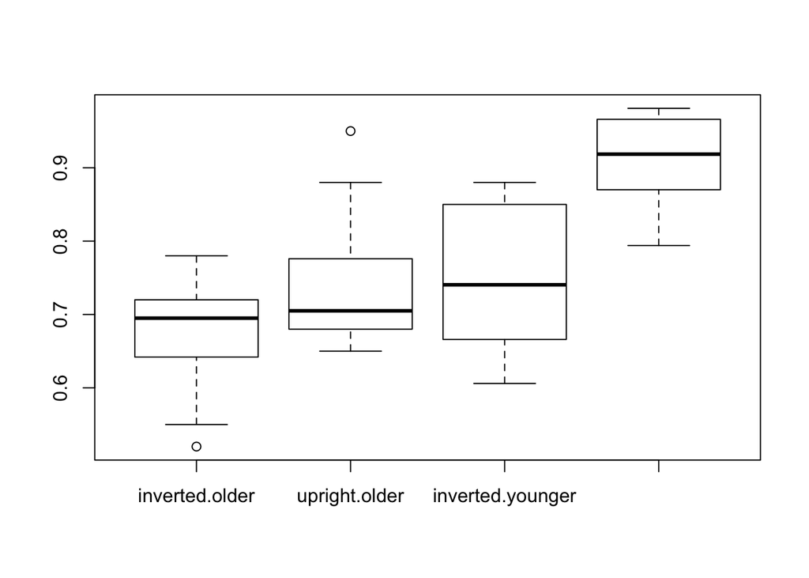

```r
boxplot(pc ~ faceOrient:ageGroup, data=faceData)
```

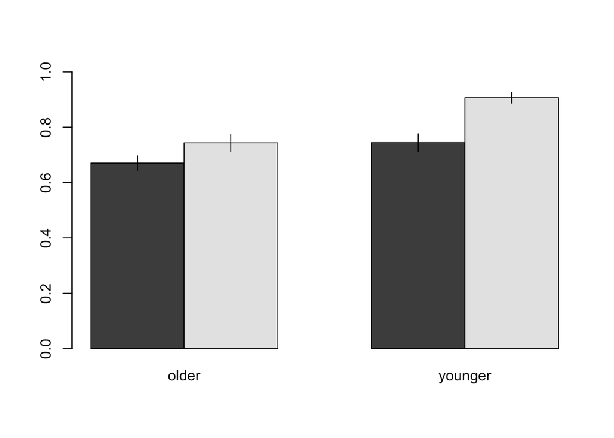

```r
## barplot the data
# calculate means / SE:
theMean <- with(faceData, tapply(pc, list(faceOrient,ageGroup), mean))
theSD <- with(faceData, tapply(pc, list(faceOrient,ageGroup), sd))
n <- with(faceData, tapply(pc, list(faceOrient,ageGroup), length))
theSE <- theSD / sqrt(n)

# plots bars; note that beside=T is needed to avoid stacked bars
bp <- barplot(theMean, ylim=c(0,1), beside=T)
segments(bp, theMean-theSE, bp, theMean+theSE) # add standard error bars
```

```r
factorial.01 <- lm(pc ~ faceOrient + ageGroup + faceOrient:ageGroup, data=faceData)
anova(factorial.01)
```

```
## Analysis of Variance Table
##
## Response: pc
##                     Df   Sum Sq  Mean Sq F value    Pr(>F)
## faceOrient           1 0.138415 0.138415 18.1106 0.0001420 ***
## ageGroup             1 0.140304 0.140304 18.3577 0.0001303 ***
## faceOrient:ageGroup  1 0.019847 0.019847  2.5968 0.1158114
## Residuals           36 0.275140 0.007643
## ---
## Signif. codes:  0 '***' 0.001 '**' 0.01 '*' 0.05 '.' 0.1 ' ' 1
```

```r
# easier way, where * factorially crosses all groups
anova(lm(pc ~ faceOrient*ageGroup, data=faceData))
```

```
## Analysis of Variance Table
##
## Response: pc
##                     Df   Sum Sq  Mean Sq F value    Pr(>F)
## faceOrient           1 0.138415 0.138415 18.1106 0.0001420 ***
## ageGroup             1 0.140304 0.140304 18.3577 0.0001303 ***
## faceOrient:ageGroup  1 0.019847 0.019847  2.5968 0.1158114
## Residuals           36 0.275140 0.007643
## ---
## Signif. codes:  0 '***' 0.001 '**' 0.01 '*' 0.05 '.' 0.1 ' ' 1
```

## Within-subjects ANOVA

Within-subject ANOVAs are typically more powerful than between-subject ANOVAs because the same participant provides data in 2 or more conditions. Therefore, unlike between-subject ANOVAs, we don’t have to worry about random inter-subject differences confounding our group differences.

```r
# modify data to have within subject ID
faceData$subjID2 <- factor(c(1:10,1:10, 11:20,11:20), label="s")

# confirm it was added to dataframe
head(faceData)
```

```
##   subjID ageGroup faceOrient    pc  rt subjID2
## 1  subj1  younger    upright 0.966 797      s1
## 2  subj2  younger    upright 0.910 664      s2
## 3  subj3  younger    upright 0.981 689      s3
## 4  subj4  younger    upright 0.890 770      s4
## 5  subj5  younger    upright 0.870 659      s5
## 6  subj6  younger    upright 0.830 748      s6
```

```r
# create the analysis of variance model
within.01 <- aov(pc ~ faceOrient + Error(subjID2), data=faceData)

# compute f-tests
summary(within.01)
```

```
##
## Error: subjID2
##           Df Sum Sq Mean Sq F value Pr(>F)
## Residuals 19 0.3404 0.01792
##
## Error: Within
##            Df  Sum Sq Mean Sq F value   Pr(>F)
## faceOrient  1 0.13842 0.13842   27.72 4.41e-05 ***
## Residuals  19 0.09487 0.00499
## ---
## Signif. codes:  0 '***' 0.001 '**' 0.01 '*' 0.05 '.' 0.1 ' ' 1
```

## Correlation

```r
# data has two dependent variables: percent correct and reaction time
head(faceData)
```

```
##   subjID ageGroup faceOrient    pc  rt subjID2
## 1  subj1  younger    upright 0.966 797      s1
## 2  subj2  younger    upright 0.910 664      s2
## 3  subj3  younger    upright 0.981 689      s3
## 4  subj4  younger    upright 0.890 770      s4
## 5  subj5  younger    upright 0.870 659      s5
## 6  subj6  younger    upright 0.830 748      s6
```

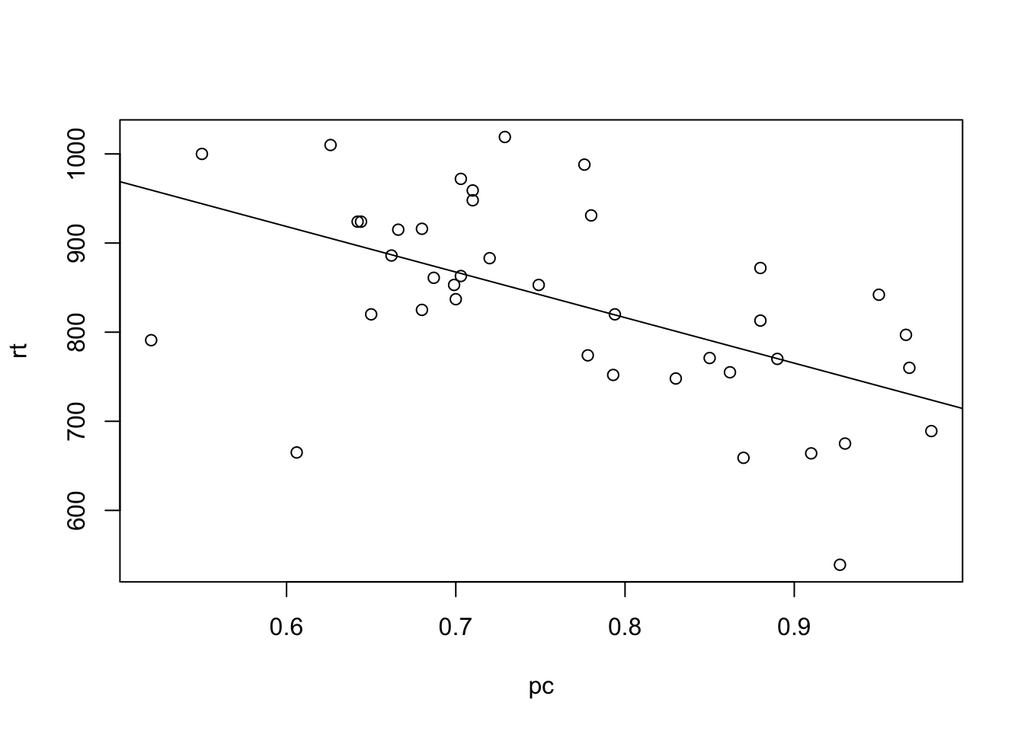

```r
with(faceData, plot(pc, rt))

cor.01 <- lm(rt ~ pc, data=faceData)
abline(cor.01)
```

```r
summary(cor.01)
```

```
##
## Call:
## lm(formula = rt ~ pc, data = faceData)
##
## Residuals:
##      Min       1Q   Median       3Q      Max
## -250.490  -52.753    0.127   58.293  166.374
##
## Coefficients:
##             Estimate Std. Error t value Pr(>|t|)
## (Intercept)  1225.21      94.71  12.936  1.7e-15 ***
## pc           -511.09     122.12  -4.185 0.000162 ***
## ---
## Signif. codes:  0 '***' 0.001 '**' 0.01 '*' 0.05 '.' 0.1 ' ' 1
##
## Residual standard error: 92.5 on 38 degrees of freedom
## Multiple R-squared:  0.3155, Adjusted R-squared:  0.2975
## F-statistic: 17.51 on 1 and 38 DF,  p-value: 0.0001624
```

```r
with(faceData, cor.test(x=pc, y=rt))
```

```
##
##  Pearson's product-moment correlation
##
## data:  pc and rt
## t = -4.1851, df = 38, p-value = 0.0001624
## alternative hypothesis: true correlation is not equal to 0
## 95 percent confidence interval:
##  -0.7431677 -0.3032417
## sample estimates:
##        cor
## -0.5616922
```

```r
# note that Pearson's r is just square-root of Regression R [sqrt(R^2)]
sqrt(0.3155) # should equal 0.56
```

```
## [1] 0.5616939
```

```r
# analysis of covariance (ANCOVA)
# note that both faceOrient and ageGroup are treated as between subj here
summary(aov(pc ~ rt + faceOrient*ageGroup, data=faceData))
```

```
##                     Df  Sum Sq Mean Sq F value   Pr(>F)
## rt                   1 0.18100 0.18100  23.618 2.45e-05 ***
## faceOrient           1 0.07304 0.07304   9.531  0.00394 **
## ageGroup             1 0.03916 0.03916   5.109  0.03013 *
## faceOrient:ageGroup  1 0.01228 0.01228   1.602  0.21401
## Residuals           35 0.26823 0.00766
## ---
## Signif. codes:  0 '***' 0.001 '**' 0.01 '*' 0.05 '.' 0.1 ' ' 1
```

# Using Packages

One reason R is a a great teaching tool is that using it well actually aides in your learning, unlike other programs such as SPSS that treat the analysis like a black-box, and you have to follow a sequence of arbitrary button-clicks to get a certain output. R, by design, requires that most of what you do is intentional.

With that said, and with R’s growing popularity, there is a massive community of developers extending the capabilities and usability of R through what are called `packages`. I’ve described some of these below. They are good shortcuts, but I really advise you do learn using the methods above, and only transition to these easier shortcuts after you know what you are doing.

## `ez` packages

This package includes several easy-to-use functions (as the name implies) for doing inferential statistics. The most useful function is the `ezANOVA()` function, which lets you do one-way, factorial, within-subject, an mixed-design ANOVAs. One extra benefit is that it automatically calculates measures of effect size (generalized eta squared) for all main effect and interactions. Where needed (within-subject factors with >2 levels) it also tests for sphericity and makes the appropriate correction (Greenhouse-Geiser or Huynh-Feldt, you choose which to report).

*Note: `packages` must be installed on each computer once, but loaded into the library each time you open R and want to use the package.*

```r
# must be installed only once on your computer using this:
# install.packages("ez") # uncomment me to install, then comment back to avoid re-install

# on every session, must load ez to library
library(ez)

# get help of what functions are included
?ez

# get help on how to use ezANOVA
?ezANOVA

# run one-way ANOVA
ezANOVA(data=faceData, dv=pc, wid=subjID, between=faceOrient)
```

```
## Coefficient covariances computed by hccm()
```

```
## $ANOVA
##       Effect DFn DFd        F           p p<.05       ges
## 1 faceOrient   1  38 12.08337 0.001289184     * 0.2412651
##
## $`Levene's Test for Homogeneity of Variance`
##   DFn DFd         SSn       SSd       F         p p<.05
## 1   1  38 0.007317025 0.1269487 2.19023 0.1471322
```

```r
# run 2x2 factorial ANOVA
ezANOVA(data=faceData, dv=pc, wid=subjID, between=.(faceOrient,ageGroup))
```

```
## Coefficient covariances computed by hccm()
```

```
## $ANOVA
##                Effect DFn DFd         F            p p<.05        ges
## 1          faceOrient   1  36 18.110611 0.0001420328     * 0.33469611
## 2            ageGroup   1  36 18.357747 0.0001303354     * 0.33772089
## 3 faceOrient:ageGroup   1  36  2.596837 0.1158114202       0.06728108
##
## $`Levene's Test for Homogeneity of Variance`
##   DFn DFd         SSn       SSd         F         p p<.05
## 1   3  36 0.008411275 0.1158815 0.8710217 0.4650753
```

```r
# run one-way within-subject ANOVA
ezANOVA(data=faceData, dv=pc, wid=subjID2, within=faceOrient)
```

```
## $ANOVA
##       Effect DFn DFd        F            p p<.05       ges
## 2 faceOrient   1  19 27.72061 4.413439e-05     * 0.2412651
```

```r
# run a mixed-design factorial ANOVA (faceOrient within, ageGroup between)
ezANOVA(data=faceData, dv=pc, wid=subjID2, within=faceOrient, between=ageGroup)
```

```
## $ANOVA
##                Effect DFn DFd         F            p p<.05        ges
## 2            ageGroup   1  18 12.620077 2.275389e-03     * 0.33772089
## 3          faceOrient   1  18 33.208916 1.838804e-05     * 0.33469611
## 4 ageGroup:faceOrient   1  18  4.761746 4.259558e-02     * 0.06728108
```

## `ggplot2` package

The default plotting tools in R are really capable, but they can get very cumbersome. One really handy and widely used package is ggplot2, and it is excellent for making all types of figures. I should note that ggplot is part of what is called the Tidyverse. The tidyverse is a whole suite of libraries that use a similar language and work really well together. Other popular packages part of the tidyverse are `dplyr`, `tidyr`, and `tibble`.

*Note that packages part of the tidyverse, and many packages not shipped with the base R, tend to use a slightly different syntax. Some prefer these, others don’t. What’s clear is that it takes a bit of time to get ued to it, but once you do get used to it, these packages are extremely helpful.*

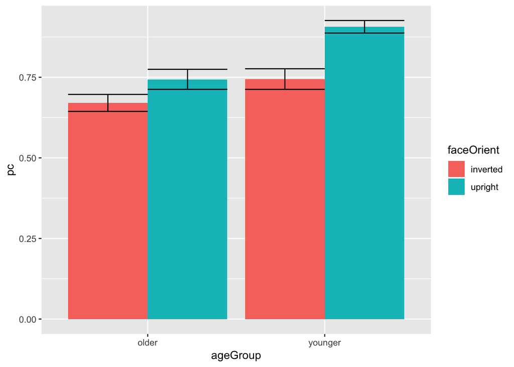

```r
# install.packages("ggplot2") # uncomment me for first time install
library(ggplot2)

# make barplot like we did earlier, but use ggplot
ggplot(data=faceData, aes(x=ageGroup, y=pc, fill=faceOrient, group=faceOrient)) +
  stat_summary(fun.y = mean, geom = "bar", position="dodge") +
  stat_summary(fun.data = mean_se, geom = "errorbar", position="dodge")
```

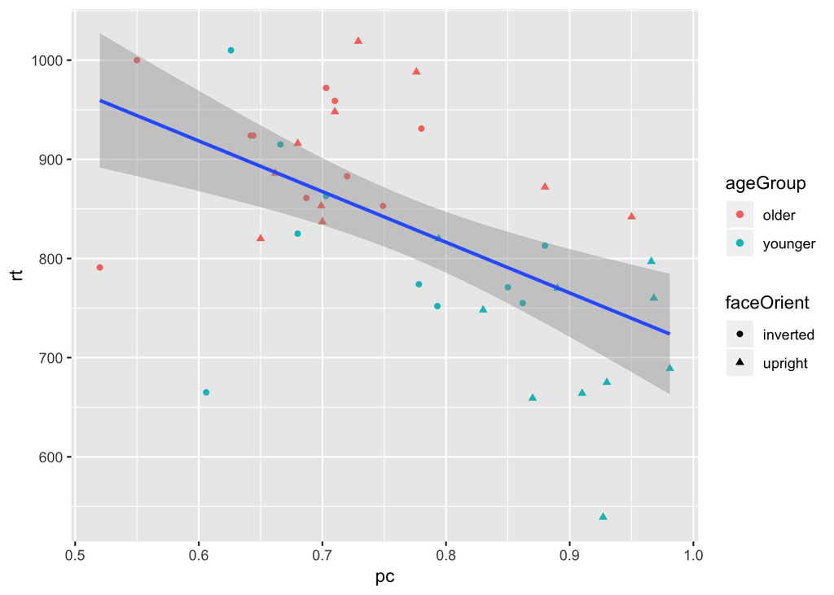

```r
# do scatter of rt ~ pc, and fit 1 line to everyone combined
ggplot(data=faceData) +
  geom_point(aes(x=pc, y=rt, col=ageGroup, shape=faceOrient)) +
  stat_smooth(aes(x=pc, y=rt), method="lm")
```

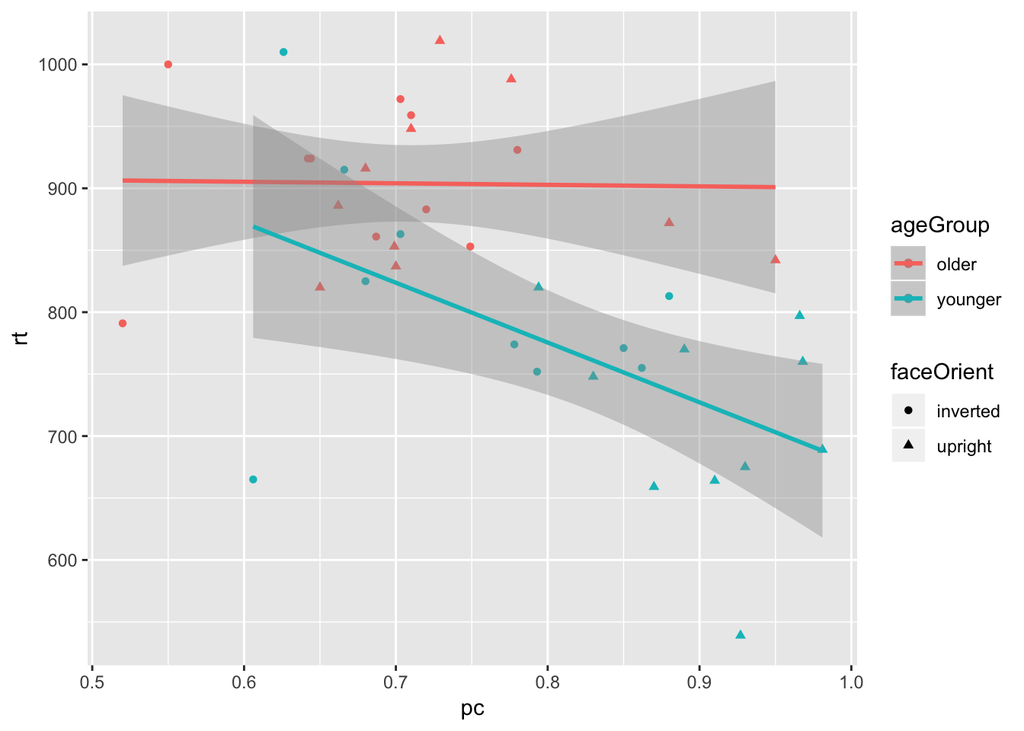

```r
# remake scatter plot, but fit line to younger and older separately
ggplot(data=faceData) +
  geom_point(aes(x=pc, y=rt, col=ageGroup, shape=faceOrient)) +
  stat_smooth(aes(x=pc, y=rt, col=ageGroup), method="lm")
```

# Other cool things & useful links

You might be surprised to learn that I made this entire document within RStudio, using something called `RMarkdown` and `knitr` (google them to learn!). I will continue to improve this document and create other resources, and will upload everything to a GitHub repository linked below. I’ve linked the “.Rmd” file used to create this document, which is the script that is capable of executing R code, as well as write PDF/HTML documents.

## Useful links:

1. Ali Hashemi’s repository for storing this document (and other resources in the future as I develop them)
- https://github.com/HashemiScience/Rintro
2. A work-in-progress statistics textbook written in R
- https://crumplab.github.io/statistics/
3. Patrick Bennett’s online resources for graduate statistic taught in McMaster’s PNB department:
- http://psycserv.mcmaster.ca/bennett/psy710/index.html
4. A gallery of nice R-made figures, and code so you can make them too:
- https://www.r-graph-gallery.com/
5. Using R for data science:
- https://r4ds.had.co.nz/
6. A series of online modules teaching descriptive/inferential statistics created by folks from the PNB department (headed by Dr. Scott Watter):
- https://macblog.mcmaster.ca/statistics/